# Projekt Speed Dating

Fran Canjuga, Gašpar Haramija, Leon Hegedić, Josipa Markić

2024-01-21

## Uvod

U ovom projektnom zadatku, naziva Speed Dating, analizirat ćemo skup podataka prikupljen između 2002. i 2004. godine u sklopu kolegija Statistička analiza podataka na Fakultetu elektrotehnike i računarstva. Dostupni su dva skupa podataka, a analizirat ćemo ih pomoću deskriptivne statistike i inferencijalne analize kako bismo dobili dublji uvid u ponašanje sudionika i međuodnose varijabli.

Ciljevi ovog projekta su upoznavanje s dostupnim podacima o sudionicima i spojevima te izvlačenje relevantnih informacija pomoću deskriptivne statistike i inferencijalne analize. Paralelno s analizom, planiramo unaprijediti svoje razumijevanje osnovnih metodologija statističke analize podataka i praktičnu primjenu programskog jezika R što ćemo primijeniti na sljedećim hipotezama na temelju kojih ćemo izvući zaključke:

1. Je li inteligencija partnera ispitanicima važnija od izgleda?
2. Postoji li razlika u interesu za gaming prema zanimanju sudionika?
3. Možemo li temeljem drugih varijabli predvidjeti hoće li se sudioniku svidjeti partner?

Počet ćemo s analizom deskriptivne statistike kako bismo stekli osnovni uvid u varijable poput starosti, spola, zanimanja i ocjena partnera. Nakon toga, primijenit ćemo inferencijalnu analizu kako bismo istražili postavljene hipoteze, uključujući pitanja o važnosti inteligencije partnera u odnosu na izgled te razlike u interesu za gaming prema zanimanju sudionika.

Ovaj projekt ima značajnost iz perspektive studenata, poput nas samih, jer nam pruža priliku primijeniti stečeno znanje o statističkoj analizi podataka u stvarnom svijetu. Uvid u ovakav skup podataka može pomoći studentima u donošenju informiranih odluka u svakodnevnom životu, bilo da se radi o razumijevanju međuljudskih odnosa ili donošenju odluka temeljenih na vlastitim preferencijama.

## Učitavanje i prikaz podataka

```r
participants = read.csv("participant_data.csv")
dates = read.csv("speed_date_data.csv")
head(participants)
```

```
##      id wave age                                  race gender
## 1 10000    1  21 Asian/Pacific Islander/Asian-American female
## 2 10001    1  24           European/Caucasian-American female
## 3 10002    1  25           European/Caucasian-American female
## 4 10003    1  23           European/Caucasian-American female
## 5 10004    1  21           European/Caucasian-American female
## 6 10005    1  23 Asian/Pacific Islander/Asian-American female
##   ambition_important attractive_important funny_important
## 1                 15                   15              15
## 2                  0                   45              20
## 3                 10                   35              10
## 4                 10                   20              20
## 5                 10                   20              25
## 6                  5                   10              25
##   intelligence_important shared_interests_important sincere_important     field
```

[output cut: 34 more lines]

```r
head(dates)
```

```
##   date_id participant_id partner_id attractive_o sincere_o intelligence_o
## 1  100000          10000      10010            6         8              8
## 2  100001          10000      10011            7         8             10
## 3  100002          10000      10012           10        10             10
## 4  100003          10000      10013            7         8              9
## 5  100004          10000      10014            8         7              9
## 6  100005          10000      10015            7         7              8
##   funny_o ambitious_o shared_interests_o attractive_partner sincere_partner
## 1       8           8                  6                  6               9
## 2       7           7                  5                  7               8
## 3      10          10                 10                  5               8
## 4       8           9                  8                  7               6
## 5       6           9                  7                  5               6
## 6       8           7                  7                  4               9
##   intelligence_partner funny_partner ambition_partner shared_interests_partner
## 1                    7             7                6                        5
## 2                    7             8                5                        6
## 3                    9             8                5                        7
## 4                    8             7                6                        8
## 5                    7             7                6                        6
## 6                    7             4                6                        4
##   like guess_prob_liked met decision
## 1    7                6   0        1
## 2    7                5   1        1
## 3    7               NA   1        1
## 4    7                6   0        1
## 5    6                6   0        1
## 6    6                5   0        0
```

Tijekom analize se može odlučiti izbaciti stupce koji nisu nužni jer ne pridonose zaključcima. Također, moguće je stvoriti pomoćne skupove podataka koji će biti korisni u određenim analizama, kao što je priprema podataka za linearnu regresiju.

Dodatno, potrebno je razmotriti promjenu klasa nekih varijabli koje nisu precizno definirane u izvornim skupovima podataka. Primjerice, varijablu “spol” možemo pretvoriti u numeričku, a za varijablu “importance_same_race” koja trenutačno ima karakterističnu klasu (character), potrebno je razmotriti njenu pravu prirodu i prilagoditi klasifikaciju prema potrebi.

U skupu podataka “dates” primjećujemo značajan broj nedostajućih podataka označenih sa NA. Prije daljnje analize, potrebno je donijeti odluku o postupanju s tim podacima, kao što je zamjena nedostajućih vrijednosti odgovarajućim podacima, brisanje redaka ili primjena drugih metoda obrade nedostajućih podataka, ovisno o kontekstu analize i željenim rezultatima.

## Deskriptivna Statistika

```r
summary(participants)
```

```
##        id             wave            age            race
##  Min.   :10000   Min.   : 1.00   Min.   :18.00   Length:540
##  1st Qu.:10141   1st Qu.: 7.00   1st Qu.:24.00   Class :character
##  Median :10276   Median :11.00   Median :26.00   Mode  :character
##  Mean   :10276   Mean   :11.11   Mean   :26.37
##  3rd Qu.:10413   3rd Qu.:15.25   3rd Qu.:28.00
##  Max.   :10550   Max.   :21.00   Max.   :55.00
##
##     gender          ambition_important attractive_important funny_important
##  Length:540         Min.   : 0.00      Min.   :  0.00       Min.   : 0.00
##  Class :character   1st Qu.: 5.00      1st Qu.: 15.00       1st Qu.:15.00
##  Mode  :character   Median :10.00      Median : 20.00       Median :18.00
##                     Mean   :10.82      Mean   : 22.52       Mean   :17.46
##                     3rd Qu.:15.00      3rd Qu.: 25.00       3rd Qu.:20.00
##                     Max.   :53.00      Max.   :100.00       Max.   :50.00
##
##  intelligence_important shared_interests_important sincere_important
##  Min.   : 0.00          Min.   : 0.000             Min.   : 0.00
##  1st Qu.:17.29          1st Qu.: 8.248             1st Qu.:15.00
##  Median :20.00          Median :10.935             Median :18.00
##  Mean   :20.17          Mean   :11.826             Mean   :17.31
##  3rd Qu.:23.02          3rd Qu.:16.000             3rd Qu.:20.00
##  Max.   :50.00          Max.   :30.000             Max.   :60.00
##
##     field           importance_same_race importance_same_religion
##  Length:540         Length:540           Min.   : 1.000
##  Class :character   Class :character     1st Qu.: 1.000
##  Mode  :character   Mode  :character     Median : 3.000
##                                          Mean   : 3.593
##                                          3rd Qu.: 6.000
##                                          Max.   :10.000
##
##      sports          tvsports        exercise          dining
##  Min.   : 1.000   Min.   : 1.00   Min.   : 1.000   Min.   : 1.000
##  1st Qu.: 4.000   1st Qu.: 2.00   1st Qu.: 5.000   1st Qu.: 7.000
##  Median : 7.000   Median : 4.00   Median : 7.000   Median : 8.000
##  Mean   : 6.409   Mean   : 4.55   Mean   : 6.278   Mean   : 7.778
##  3rd Qu.: 9.000   3rd Qu.: 7.00   3rd Qu.: 8.000   3rd Qu.: 9.000
##  Max.   :10.000   Max.   :10.00   Max.   :10.000   Max.   :10.000
##
```

[output cut: 33 more lines]

```
##  Min.   : 0.000       Min.   : 1.000   Min.   : 2.000   Min.   : 2.000
##  1st Qu.: 2.000       1st Qu.: 6.000   1st Qu.: 8.000   1st Qu.: 7.000
##  Median : 3.000       Median : 7.000   Median : 8.000   Median : 8.000
##  Mean   : 3.043       Mean   : 7.052   Mean   : 8.275   Mean   : 7.714
##  3rd Qu.: 4.000       3rd Qu.: 8.000   3rd Qu.: 9.000   3rd Qu.: 9.000
##  Max.   :18.000       Max.   :10.000   Max.   :10.000   Max.   :10.000
##  NA's   :73           NA's   :5        NA's   :2        NA's   :2
##      funny           ambition            X
##  Min.   : 3.000   Min.   : 2.000   Min.   :4.000
##  1st Qu.: 8.000   1st Qu.: 7.000   1st Qu.:7.000
##  Median : 8.000   Median : 8.000   Median :8.000
##  Mean   : 8.387   Mean   : 7.589   Mean   :7.571
##  3rd Qu.: 9.000   3rd Qu.: 9.000   3rd Qu.:9.000
##  Max.   :10.000   Max.   :10.000   Max.   :9.000
##  NA's   :2        NA's   :2        NA's   :533
```

```r
summary(dates)
```

```
##     date_id       participant_id    partner_id     attractive_o
##  Min.   :100000   Min.   :10000   Min.   :10000   Min.   : 0.000
##  1st Qu.:102149   1st Qu.:10155   1st Qu.:10155   1st Qu.: 5.000
##  Median :104171   Median :10278   Median :10278   Median : 6.000
##  Mean   :104187   Mean   :10282   Mean   :10282   Mean   : 6.194
##  3rd Qu.:106268   3rd Qu.:10405   3rd Qu.:10405   3rd Qu.: 8.000
##  Max.   :108377   Max.   :10550   Max.   :10550   Max.   :10.500
##                                                   NA's   :176
##    sincere_o      intelligence_o      funny_o        ambitious_o
##  Min.   : 0.000   Min.   : 0.000   Min.   : 0.000   Min.   : 0.00
##  1st Qu.: 6.000   1st Qu.: 6.000   1st Qu.: 5.000   1st Qu.: 6.00
##  Median : 7.000   Median : 7.000   Median : 7.000   Median : 7.00
##  Mean   : 7.185   Mean   : 7.381   Mean   : 6.409   Mean   : 6.79
##  3rd Qu.: 8.000   3rd Qu.: 8.000   3rd Qu.: 8.000   3rd Qu.: 8.00
##  Max.   :10.000   Max.   :10.000   Max.   :11.000   Max.   :10.00
##  NA's   :247      NA's   :268      NA's   :321      NA's   :678
##  shared_interests_o attractive_partner sincere_partner  intelligence_partner
##  Min.   : 0.000     Min.   : 0.000     Min.   : 0.000   Min.   : 0.000
##  1st Qu.: 4.000     1st Qu.: 5.000     1st Qu.: 6.000   1st Qu.: 6.000
##  Median : 6.000     Median : 6.000     Median : 7.000   Median : 7.000
##  Mean   : 5.489     Mean   : 6.194     Mean   : 7.185   Mean   : 7.381
##  3rd Qu.: 7.000     3rd Qu.: 8.000     3rd Qu.: 8.000   3rd Qu.: 8.000
##  Max.   :10.000     Max.   :10.000     Max.   :10.000   Max.   :10.000
##  NA's   :1029       NA's   :176        NA's   :247      NA's   :268
##  funny_partner    ambition_partner shared_interests_partner      like
##  Min.   : 0.000   Min.   : 0.00    Min.   : 0.000           Min.   : 0.000
##  1st Qu.: 5.000   1st Qu.: 6.00    1st Qu.: 4.000           1st Qu.: 5.000
##  Median : 7.000   Median : 7.00    Median : 6.000           Median : 6.000
##  Mean   : 6.409   Mean   : 6.79    Mean   : 5.489           Mean   : 6.142
##  3rd Qu.: 8.000   3rd Qu.: 8.00    3rd Qu.: 7.000           3rd Qu.: 7.000
##  Max.   :10.000   Max.   :10.00    Max.   :10.000           Max.   :10.000
##  NA's   :321      NA's   :678      NA's   :1029             NA's   :213
##  guess_prob_liked      met            decision
##  Min.   : 0.000   Min.   :0.0000   Min.   :0.0000
##  1st Qu.: 4.000   1st Qu.:0.0000   1st Qu.:0.0000
##  Median : 5.000   Median :0.0000   Median :0.0000
##  Mean   : 5.216   Mean   :0.0501   Mean   :0.4221
##  3rd Qu.: 7.000   3rd Qu.:0.0000   3rd Qu.:1.0000
##  Max.   :10.000   Max.   :8.0000   Max.   :1.0000
##  NA's   :278      NA's   :343
```

```r
cat("Dimenzija podataka o participantima: ", dim(participants))
```

```
## Dimenzija podataka o participantima:  540 40
```

```r
cat("Dimenzija podataka o spojevima: ", dim(dates))
```

```
## Dimenzija podataka o spojevima:  8086 19
```

Na temelju dostupnih podataka saznajemo da skup podataka za sudionike sadrži podatke o 540 sudionika te 40 stupaca, dok skup podataka o spojevima sadrži podatke o 8086 spojeva i ima 19 stupaca.

Na temelju predefiniranih hipoteza možemo zaključiti da svi stupci u podatcima nisu jednako relevantni. U slučaju analize je li inteligencija partnera važnija od fizičkog izgleda od najveće su važnosti podaci vezani uz inteligenciju i fizički izgled. Analogno za analizu povezanosti gaminga i zanimanja participanta najvažniji su podaci vezani uz gaming i samo područje zanimanja participanta.

Promotrimo relevantne varijable koje ćemo kasnije koristiti u istraživačkim pitanjima. U vezi prvog pitanja bitni su nam inteligencija i fizički izgled partnera.

### Je li inteligencija partnera ispitanicima važnija od izgleda?

Za rješavanje ovog pitanja ključni su nam podaci o važnosti izgleda i inteligencije među ispitanicima. Ovi podaci nalaze se u okviru varijabli “attractive_important” i “intelligence_important” unutar skupa podataka “participants”. Kako bismo izbjegli eventualne smetnje u analizi, početno ćemo ukloniti sve null ili nedostajuće vrijednosti iz ovih varijabli.

```r
cleaned_intelligence <- na.omit(participants$intelligence_important)
cleaned_attractiveness <- na.omit(participants$attractive_important)
```

```r
cat("Prosječna ocjena važnosti inteligencije kod partnera iznosi",mean(participants$intelligence_important),'\n')
```

```
## Prosječna ocjena važnosti inteligencije kod partnera iznosi 20.17174
```

```r
cat("Prosječna ocjena važnosti izgleda kod partnera iznosi",mean(participants$attractive_important),'\n')
```

```
## Prosječna ocjena važnosti izgleda kod partnera iznosi 22.52019
```

Prema podacima srednja vrijednost važnosti inteligencije, manja je od važnosti izgleda kod ispitanika.

Podatke ćemo prikazati uz pomoć histograma.

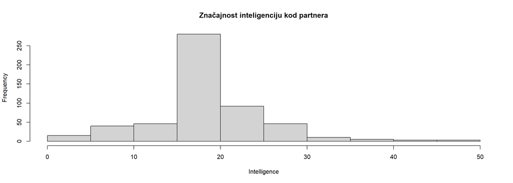

```r
hist(na.omit(participants$intelligence_important), main='Značajnost inteligenciju kod partnera', xlab='Intelligence', ylab='Frequency')
```

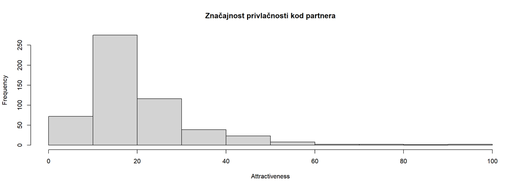

```r
hist(na.omit(participants$attractive_important), main='Značajnost privlačnosti kod partnera', xlab='Attractiveness', ylab='Frequency')
```

Slično kao i kod važnosti inteligencije, najčešća ocjena važnosti privlačnosti je između 10 i 20.

Podatke o važnosti atraktivnosti i inteligencije ćemo usporediti u histogramu.

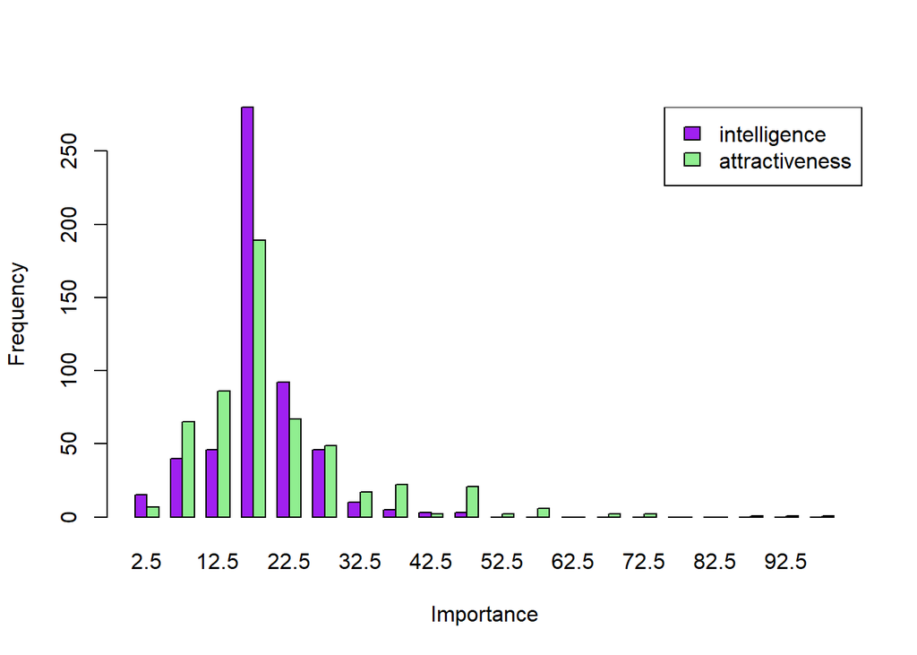

```r
merged_data <- inner_join(participants, dates, by = c("id" = "participant_id"))

b <- seq(0, 100, by = 5)

h1 <- hist(cleaned_intelligence, breaks = b, plot = FALSE)
h2 <- hist(cleaned_attractiveness, breaks = b, plot = FALSE)


midpoints <- (head(b, -1) + tail(b, -1)) / 2

data <- t(cbind(h1$counts, h2$counts))

barplot(data, beside = TRUE, col = c("purple", "lightgreen"), xlab = "Importance", ylab = 'Frequency', names.arg = midpoints)
legend("topright", c("intelligence", "attractiveness"), fill = c("purple", "lightgreen"))
```

Za provjeru normalnosti podataka planiramo koristiti qq-plotove i test o jednakosti varijanci.

[figure not shown]

```r
qqnorm(cleaned_intelligence, pch = 1, frame = FALSE, main = "Važnost izgleda")
qqline(cleaned_attractiveness, col = "blue", lwd = "2")
```

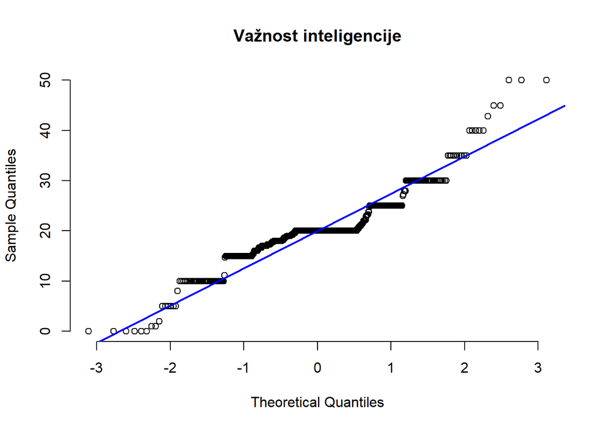

```r
# QQ plot for intelligence_important without NA values
qqnorm(cleaned_intelligence, pch = 1, frame = FALSE, main = "Važnost inteligencije")
qqline(cleaned_attractiveness, col = "blue", lwd = "2")
```

Uz pretpostavku normalnosti podataka možemo nastaviti testiranje varijanca.

Provest ćemo test o jednakosti varijanci uz pomoć F-testa.
$$F = \frac{S_{X_1}^2 / \sigma_1^2}{S_{X_2}^2 /
\sigma_2^2}$$
Pri ćemu za statistike s1 (intelligence_important) i s2 (attractive_important) vrijedi :
$$S_{X_1}^2 = \frac{1}{n_1 - 1} \sum_{i = 1}^{n_1}
(X_1^i - \bar{X}_1)^2, \quad S_{X_2}^2 = \frac{1}{n_2 - 1} \sum_{i =
1}^{n_2} (X_2^i - \bar{X}_2)^2.$$
Uz $(n_1 - 1, n_2 - 1)$ stupnjeva slobode. Hipoteze testa o jednakosti varijanca glase :
$$\begin{aligned}
H_0&: \sigma_1^2 = \sigma_2^2 \\
H_1&: \sigma_1^2 \neq \sigma_2^2
\end{aligned}$$

Varijanca važnosti izgleda:

```r
var_attractive <- var(cleaned_attractiveness)
cat("Varijanca od attractive_important:", var_attractive, "\n")
```

```
## Varijanca od attractive_important: 162.2717
```

Varijanca važnosti inteligencije:

```r
var_intelligence <- var(cleaned_intelligence)
cat("Varijanca od intelligence_important:", var_intelligence, "\n")
```

```
## Varijanca od intelligence_important: 47.30045
```

Te radimo F-test:

```r
var.test(cleaned_attractiveness, cleaned_intelligence)
```

```
##
##  F test to compare two variances
##
## data:  cleaned_attractiveness and cleaned_intelligence
## F = 3.4307, num df = 539, denom df = 539, p-value < 2.2e-16
## alternative hypothesis: true ratio of variances is not equal to 1
## 95 percent confidence interval:
##  2.897158 4.062401
## sample estimates:
## ratio of variances
##           3.430659
```

Zaključujemo uz p-vrijednost od 2.2e-16 da su varijance različite. Odbacujemo H0 hipotezu u koristi H1 te ćemo koristiti T-test za dva uzorka uz nejednake varijance.

Sada provodimo t-test za dva uzorka uz nepoznate i nejednake varijance.

$$\begin{aligned}
H_0&: \mu_1 ≥ \mu_2 \\
H_1&: \mu_1 < \mu_2
\end{aligned}$$

```r
t_test_result <- t.test(cleaned_intelligence,
                        cleaned_attractiveness,
                        var.equal = FALSE)

print(t_test_result)
```

```
##
##  Welch Two Sample t-test
##
## data:  cleaned_intelligence and cleaned_attractiveness
## t = -3.7697, df = 828.62, p-value = 0.000175
## alternative hypothesis: true difference in means is not equal to 0
## 95 percent confidence interval:
##  -3.571237 -1.125652
## sample estimates:
## mean of x mean of y
##  20.17174  22.52019
```

Uz malu p-vrijednost od 0.000175 odbacujemo hipotezu H0 u korist H1.

Možemo zaključiti da je ispitanicima inteligencija nije važnije od izgleda, te podaci upućuju da je odnos važnosti inteligencije i izgleda suprotan od postvaljenog istraživačkog pitanja.